# El mundo necesita un padre

Autor

Angel Feliz

## Prefacio

*La única cosa necesaria para que el mal triunfe es que los hombres de buenos no hagan nada.*

**Edmund Burke**

## 01 - !Satanás vieno a la tierra, señor!

- Narra una historia muy violeta en Africa.
- Algunos de los jovenes que realizarón el acto frequentaban la iglesia
- Dios le reveló a Cassie que la ausencia fue la causa.
- Para entrenar a los jovenes es necesario mostrar **ejemplos que puedan imitar**.

## 01 - !Satanás vieno a la tierra, señor!

Basado en Luchas 1:17 tenemos los siguientes puntos:

1. Volver los **corazones de los padres hacia los hijos**.
2. Volver al **desobediente** hacia la **sabiduría de Dios**.
3. Preparar a las personas para que estén **listas para el Señor**.

## 02 - El clamor de los niños

Los hombres se han distinguido por ser un mal ejemplo para sociadad:

- [70% - 90%] de los crímenes mayores
- 97% de los violadores
- 75% de conductores borrachos

## 02 - El clamor de los niños

*Los padres han* **delegado** *demasido de la crianza a las* **madres**. El libro presenta algunas estadísticas que distinguen a los niños que se crian sin sus padres, esto distinguen al:

- 63% de los suicidios
- 80% de los violadores
- Tienen el doble de problemas emocionales y conducta
- Tienen una tasa de termino educativo más bajo
- Son más dados a usar drogas

## 02 - El clamor de los niños

Por otra parte en esta demostado que si los padres están presentes podemos ver que los hijos:

- Son más resistentes ante situacione extresantes
- Son más capaces de solucionar problemas y adaptarnos
- Tienen mayor habilidad para tomar iniciativa
- Tienen relaciones positivas, son populares y queridos

## 02 - El clamor de los niños

Por otra parte en esta demostado que si los padres están presentes podemos ver que los hijos:

- Tienen amistades de largo plazo
- Tienen matrimonios exitosos
- Son menos propensos a morir en la infancia (1.8 veces menos)
- Son menos propensos a sufrir de asma
- Son menos propensos a ser obesos

## 02 - El clamor de los niños

*La primera percepción que tienen los hijos sobre Dios está relacionada con la manera en que los tratos*, por lo que dependiendo de nuestro trato nuestros hijos pueden entender que **Dios padre** es:

- Ausente o desconectado
- Permisivo
- Negligente
- Emocional

## 03 - Cada época cuenta

*Es necesario que seamos moldeados por personas con roles específicos durante cada etapa* para evitar ser marcodos con **cicatrices** al largo plazo.

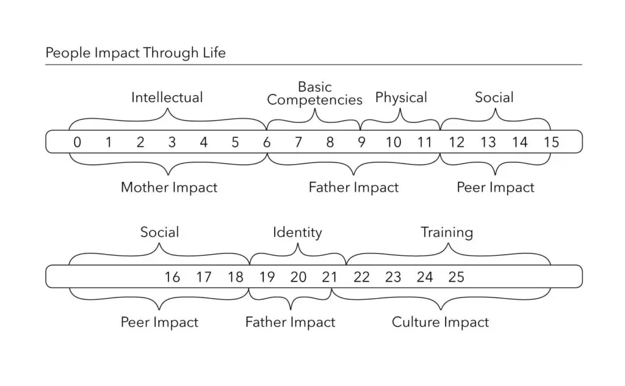

Tal como puede ver en el diagrama cada etapa cuenta con actor principal, que tiene funciones indispensables para esas edades.

## 03 - Cada época cuenta: Madre (0-5 años)

[output not shown]

## 03 - Cada época cuenta: Padre (6-11 años)

[output not shown]

## 03 - Cada época cuenta: Grupo (12-18 años)

Durante esta etapa los padres deben *hábilmente* **auditar** e **impactar** al grupo de amigos para que adopten los valores correctos.

| Años | Objetivos |
| --- | --- |
| [12] | - Decifrar dónde encajan es la búsqueda más escencial. |
| [13] | - Los padres deben dejar de tratar como un niño al adolescente y dejarselo saber. (*Cap. 13*) |
| [14-18] | - Desarrollar capacidad de liderazgo e inteligencia emocional. |

## 03 - Cada época cuenta: Padre (19-21 años)

| Años | Objetivos |
| --- | --- |
| [19-20] | - Objetivo principal es establer la **identidad personal** (*Cap. 7*) y crear una contribución significativa en la vida. - Los padres son la fuente de sabiduría para prepararse la vida adulta. |
| [21] | - El padre de afirmar la confiza que tiene en su hijo como un adulto (*Cap 9*). |

## 03 - Cada época cuenta: tiempo de éxito (22-42 años)

[output not shown]

## 03 - Cada época cuenta: Medio tiempo (43-48 años)

*En este etapa tomamos una pausa para evaluar la manera en la que hemos vivido hasta el momento y comenzamos a pensar en el legado que queremos dejar* Ante esto tenemos tres alternativas:

- Continuar como vamos con **indiferencia** sin ninguna visión o pasión.
- Te enfocas satisfacer tus necesidades acumlando poseciones.
- Te enforcas en **enfluenciar** a otros para bien.

*Esta etapa puede ocurrir más tarde en mujeres con varios hijos.*

## 03 - Cada época cuenta: Segunda mitad (49-70 años)

*El resultado del medio tiempo es vivir en la plenitud del próposito que queremos lograr*.

## 03 - Cada época cuenta: Segunda mitad (71 o más años)

- Podemos movernos a modo de superviviencia.
- Podemos motivar a otros a seguir nuestra misión.